# PSTAT 100 - Data Science Concepts and Analysis

## Welcome to PSTAT 100!

- Syllabus
- Data Science Life Cycle
- Data and Story-telling

# Syllabus

## People

- Instructor: Alexander Franks, PhD
- Teaching Assistant: Claire Gan
- Teaching Assistant: Yuting Ma
- Teaching Assistant: Yaoyuan Xu

## Assessments

Homework + In-person exams + Weekly Quizzes

## Homework case studies: a preview

## Case study 1: ACE and health

Association between Adverse Childhood Experiences (ACE) and general health.

[figure not shown]

## Case study 1: ACE and health

You will:

- Process 10K survey responses from CDC’s Behavioral Risk Factor Surveillance System (BRFSS)

## Case study 2: SEDA

**Stanford Education Data Archive**

Relationship between education achievement gaps and socioeconomic indicators.

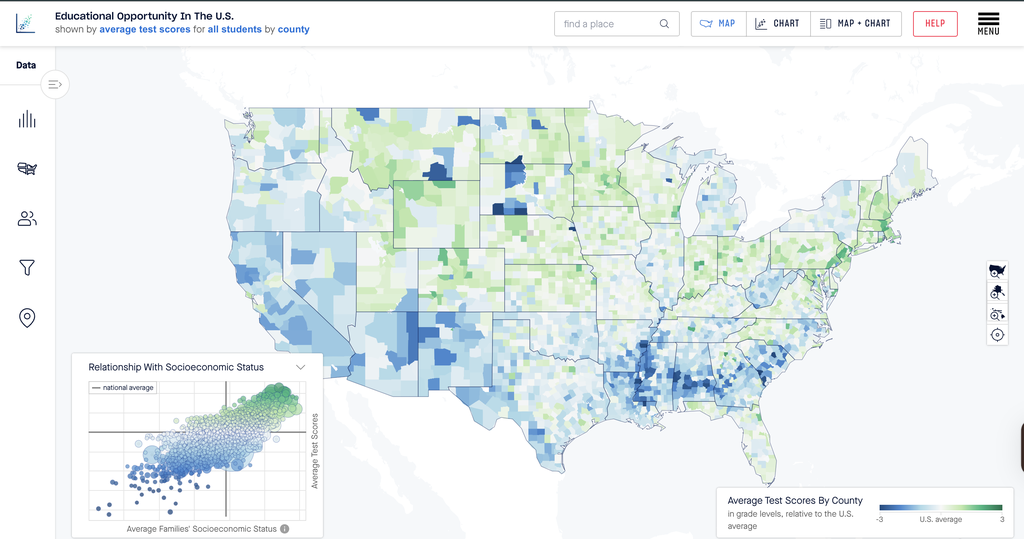

## Case study 3: Discrimination at DDS?

Apparent disparity in allocation of California Department of Developmental Services (DDS) benefits across racial groups.

> *…the average annual spending on Hispanic consumers was approximately one-third of that on White non-Hispanic consumers…*

Is there systematic discrimination, or are we not assessing the data carefully enough?

## Case study 4: Paleoclimatology

How diatom abundance reveals climate condition changes long time ago.

(Diatoms are one type of algae with glass bodies. They preserve extraordinarily well over time).

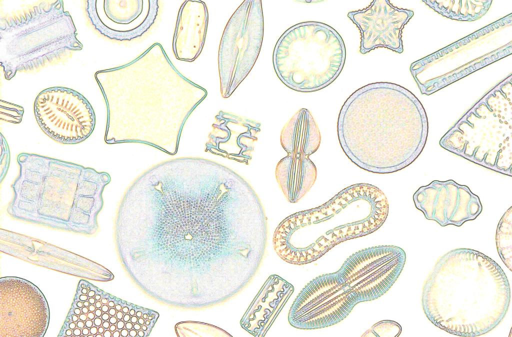

Analyze diatom relative abundances from ocean sediment cores (tubes of ocean mud) spanning ~15k years.

## Assessments: Exams

- **In-person, closed-book exams** (20+30 = 50% final grade weight)
  - Exams emphasize conceptual understanding, decision-making, and data science principles (not extended mathematical calculation).
  - Questions can come from lecture slides and homework assignments.
  - **Midterm (20%): Tuesday 11/3 In class.**
  - **Final (30%): Monday 12/7 at 12pm.**

## Assessments: Exams

Midterm: Fall 25

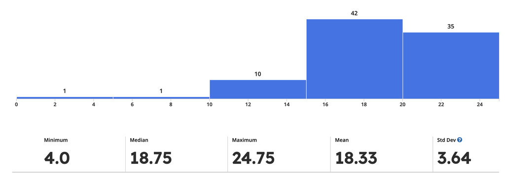

Final: Fall 25

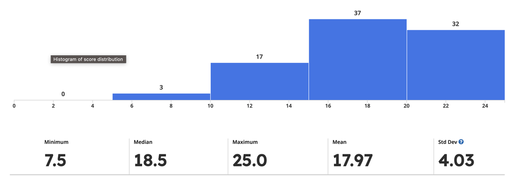

## Assessments: Quizzes

- Weekly in-class quizzes starting the week 10/6
- 8 quizzes, lowest 2 scores dropped
- Approximately three or four multiple choice or true/false questions to check basic comprehension
- 20% of final course grade

## Office Hours

Please check the syllabus file on Canvas.

## AI policy

- You may consult AI for help but **all written answers must be in your own words**
- **Students caught directly copy and pasting AI content into their assignments will be given a zero.**
- Better understanding of the subject leads to better usage of the tools.
- We, rather than tools, will be responsible for our decisions and their consequences.
- In job interviews they may ask you to explain AI generated code

## Tentative schedule

- Week 1-2: the Tidy data standard and `tidyverse`
- Week 3-4: Sampling, study design and missingness.
- Week 5: Data visualization
- Week 6: Uncertainty Quantification
- Week 8-10: Linear regression, logistic regression, data privacy, principal component analysis and parallel computing.

# Data Science Life Cycle

## Scope

- **Communication**: Designs and goals of a study, visualization
- **Mathematics**: *engineering* math. Please review basic linear algebra (matrix, eigenvalue) and calculus.
- **Computing**: Build data pipelines. Simulation-based method evaluation. Extensive `R` coding.
- **Ethics**: The responsible collection, analysis, and application of data to protect individual rights and prevent societal harm

This class emphasizes the connections between math, code, data and ethics.

## Data science lifecycle

There is a consensus that doing data science involves proceeding through a **lifecycle**: *a repeated sequence of steps.*

- Less consensus at the moment about how many steps and what they are. Below is a chart from Yu and Barter, 2024.

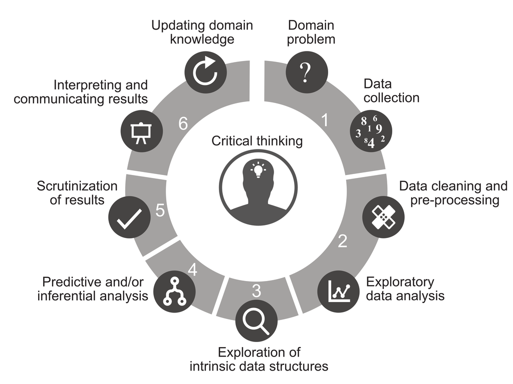

## Illustrating the cycle

We’ll walk through a very simple example to get a concrete idea of how the cycle works.

**Question**: *Do large animals have larger brains? How much larger?*

You will see some code displayed as we walk through the example.

Don’t worry about understanding them—that’s what this course is for.

## Step 0: Domain problem

There are lots of datasets out there with brain and body **weight** measurements, let’s make the question a bit more specific.

- *What is the relationship between an animal’s brain and body weight?*

Other aspects of brain–body relationships can also be intriguing, but we are starting small.

## Step 1: Collect

Acquire a publicly available dataset comprising average body and brain weights for 62 mammals.

```r
# import brain and body weights
bb_weights <- read_csv('data/allison1976.csv') |> select(1:3)
head(bb_weights, n=5)
```

```
# A tibble: 5 × 3
  species                body_wt brain_wt
  <chr>                    <dbl>    <dbl>
1 Africanelephant        6654      5712
2 Africangiantpouchedrat    1         6.6
3 ArcticFox                 3.38     44.5
4 Arcticgroundsquirrel      0.92      5.7
5 Asianelephant          2547      4603
```

**Units of measurement**

- body weight in kilograms
- brain weight in grams

## Step 2: Acquaint

**Especially because we didn’t collect this data ourselves**, we should do a little background research to understand where the data came from (Allison *et al.* 1976) and what limitations might exist:

- Information on mammals only: no data on birds, fish, reptiles, etc.
- Species were not chosen to represent all mammals: probably shouldn’t generalize.

## Step 3: Tidy—Clean up and organize

This dataset is already impeccably neat: each row is an observation for some mammal, and the columns are the two variables (average weights).

So no tidying needed—we’ll just check the dimensions and see if any values are missing.

```r
# dimensions?
dim(bb_weights)
```

```
[1] 62  3
```

```r
# missing values?
colSums(is.na(bb_weights))
```

```
 species  body_wt brain_wt
       0        0        0
```

## Step 4: Explore

Look for patterns, structure, properites

Visualization is usually a good starting point.

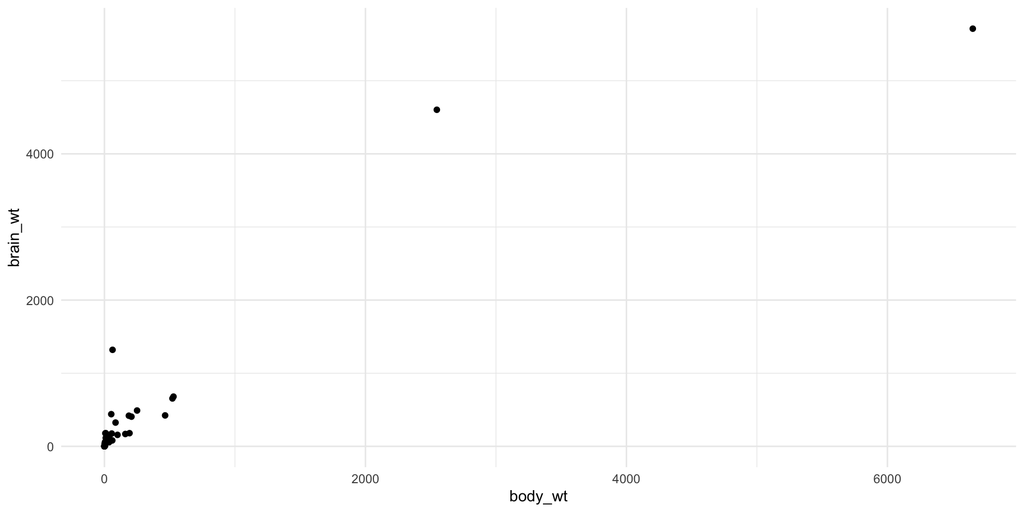

```r
# plot
ggplot(bb_weights, aes(x = body_wt, y = brain_wt)) +
  geom_point() +
  theme_minimal()
```

How do you feel about this plot? Do you see any patterns?

Do you see any problems with this presentation?

## Step 4: Explore

A simple axis transformation reveals a clearer pattern. (And the labels encode more information too).

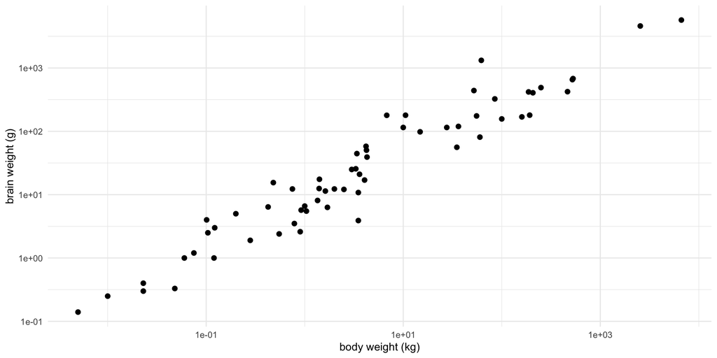

```r
ggplot(bb_weights, aes(x = body_wt, y = brain_wt)) +
  geom_point(size = 2) +
  theme_minimal() +
  scale_x_log10(name = "body weight (kg)") +
  scale_y_log10(name = "brain weight (g)")
```

## Step 5: Analyze

The plot shows us that there’s a roughly linear relationship on the log scale:

$$\log(\text{brain}) = \alpha \log(\text{body}) + c$$

We can use some statistical methods to estimate the parameters $\alpha$ and $c$.

## Step 6: Interpret

So what does that mean in terms of brain and body weights? A little algebra and we have:

$$(\text{brain}) \propto (\text{body})^\alpha$$

Can someone help me to fill in the math?

This is known as a “power-law” relationship: brain weight changes in proportion to a power of body weight.

So it appears that for these 62 mammals, the brain-body scaling is well-described by a power law. (Notice: no generalization/extrapolation!)

## Next Cycle

We can now engage in question refinement. Do other classes of animal exhibit the same power law relationship? Is it the same or different from class to class?

To investigate, we need richer data.

# Appendix: Power-law of animal brain weights

We present the second data science life cycle using the enriched data.

## Step 1: Collect

A number of authors have studied this problem, and, lucky us, relevant datasets are publicly available as well.

Below, we’ll import a few of these datasets for three different animal classes.

```r
# import meta analysis datasets
library(tidyverse)
reptiles <- read_csv('data/reptile_meta.csv')
birds <- read_csv('data/bird_meta.csv')
mammals <- read_csv('data/mammal_meta.csv')
```

```r
head(reptiles, n = 3)
```

```
# A tibble: 3 × 17
  Order Family Genus Species Subspecies Genus_species `Sample size` Sex   Method
  <chr> <chr>  <chr> <chr>   <lgl>      <chr>                 <dbl> <chr> <chr>
1 Croc… Allig… Alli… missis… NA         Alligator_mi…             1 m     Mass
2 Croc… Allig… Alli… missis… NA         Alligator_mi…             1 m     Mass
3 Croc… Croco… Croc… acutus  NA         Crocodylus_a…             1 f     Mass
# ℹ 8 more variables: `Body weight (g)` <dbl>, `SVL (mm)` <dbl>,
#   `Brain weight (g)` <dbl>, `Brain volume (mm3)` <dbl>, `Age Class` <chr>,
#   `Species Name in original article` <chr>, Reference <chr>, Remark <chr>
```

```r
glimpse(reptiles)
```

```
Rows: 192
Columns: 17
$ Order                              <chr> "Crocodilia", "Crocodilia", "Crocod…
$ Family                             <chr> "Alligatoridae", "Alligatoridae", "…
$ Genus                              <chr> "Alligator", "Alligator", "Crocodyl…
$ Species                            <chr> "mississippiensis", "mississippiens…
$ Subspecies                         <lgl> NA, NA, NA, NA, NA, NA, NA, NA, NA,…
$ Genus_species                      <chr> "Alligator_mississippiensis", "Alli…
$ `Sample size`                      <dbl> 1, 1, 1, 1, 1, 1, 1, 1, 1, 1, 1, 1,…
$ Sex                                <chr> "m", "m", "f", "unknown", "unknown"…
$ Method                             <chr> "Mass", "Mass", "Mass", "Mass", "Ma…
$ `Body weight (g)`                  <dbl> 205000.000, 173000.000, 134000.000,…
$ `SVL (mm)`                         <dbl> NA, NA, NA, NA, NA, NA, NA, NA, NA,…
$ `Brain weight (g)`                 <dbl> 14.080, 11.200, 15.600, 11.000, 0.1…
$ `Brain volume (mm3)`               <dbl> NA, NA, NA, NA, NA, NA, NA, NA, NA,…
$ `Age Class`                        <chr> "Adult", "Adult", "Adult", "Adult",…
$ `Species Name in original article` <chr> NA, NA, NA, NA, NA, NA, NA, NA, NA,…
$ Reference                          <chr> "Crile G and Quiring DP (1940) Ohio…
$ Remark                             <chr> NA, NA, "Cat.nm:183", NA, NA, NA, N…
```

```r
glimpse(birds)
```

```
Rows: 10,176
Columns: 20
$ Order               <chr> "Accipitriformes", "Accipitriformes", "Accipitrifo…
$ Family              <chr> "Accipitridae", "Accipitridae", "Accipitridae", "A…
$ Genus               <chr> "Accipiter", "Accipiter", "Accipiter", "Accipiter"…
$ Species             <chr> "cirrocephalus", "cirrocephalus", "cirrocephalus",…
$ Subspecies          <chr> NA, NA, NA, NA, NA, NA, NA, NA, NA, NA, NA, NA, "g…
$ Genus_Species       <chr> "Accipiter_cirrocephalus", "Accipiter_cirrocephalu…
$ Sex                 <chr> "f", "f", "f", "m", "f", "f", "f", "m", "m", "f", …
$ `Sample size`       <dbl> 1, 1, 1, 1, 1, 1, 1, 1, 1, 1, 1, 1, 1, 1, 1, 1, 1,…
$ `Brain Volume (ml)` <dbl> 2.5, 2.4, 2.6, 2.2, 5.2, 3.8, 4.0, 4.8, 4.0, 4.7, …
$ Method              <chr> "Vol", "Vol", "Vol", "Vol", "Vol", "Vol", "Vol", "…
$ `Brain mass (g)`    <dbl> NA, NA, NA, NA, NA, NA, NA, NA, NA, NA, NA, NA, 7.…
$ `Body mass (g)`     <dbl> 202.7, 203.9, 200.5, 137.5, 414.0, 334.0, 323.2, 3…
$ `Specimen ID`       <chr> "MV B16071", "MV B20243", "MVW9876", "MVW6745", "U…
$ Museum              <chr> "Museum Victoria", "Museum Victoria", NA, NA, "Nat…
$ `Date (mm-dd-yyyy)` <chr> NA, NA, NA, NA, NA, NA, NA, NA, NA, NA, NA, NA, "5…
$ Locality            <chr> NA, NA, NA, NA, NA, NA, NA, NA, NA, NA, NA, NA, "\…
$ Coordinate          <chr> NA, NA, NA, NA, NA, NA, NA, NA, NA, NA, NA, NA, "5…
$ `Age Class`         <chr> "unknown", "unknown", "unknown", "unknown", "unkno…
$ Reference           <chr> "This study (Andrew Iwaniuk unpublished data)", "T…
$ Remark              <chr> NA, NA, NA, NA, NA, NA, NA, NA, NA, NA, NA, NA, NA…
```

## Step 2: Acquaint

The data we just showed are basically a convenience sample of existing scientific studies.

- Multiple studies: possibly different sampling and measurement protocols.
- Criteria for inclusion unknown: probably neither comprehensive nor representative.

So these data, while richer, are still relatively narrow in terms of generalizability.

## Step 3: Tidy

These datasets are still quite neat, but have a few minor things out of order.

```r
# variable names and positions don't quite match up
# Original: Variable selection and renaming
rept_vars <- c(1, 2, 3, 4, 8, 10, 12)
bird_vars <- c(1, 2, 3, 4, 7, 12, 11)
mammal_vars <- c(1, 2, 3, 4, 7, 15, 12)
```

```r
# Rename and combine datasets
rept <- reptiles |>
  select(all_of(rept_vars)) |>
  rename(body = `Body weight (g)`,
         brain = `Brain weight (g)`) |>
  mutate(class = "Reptile")

bird <- birds |>
  select(all_of(bird_vars)) |>
  rename(body = `Body mass (g)`,
         brain = `Brain mass (g)`) |>
  mutate(class = "Bird")

mamm <- mammals |>
  select(all_of(mammal_vars)) |>
  rename(body = `Body mass (g)`,
         brain = `Brain mass (g)`) |>
  mutate(class = "Mammal")

# Combine datasets
three_kind <- bind_rows(rept, mamm, bird)
head(three_kind, 5)
```

```
# A tibble: 5 × 8
  Order      Family        Genus      Species          Sex     body  brain class
  <chr>      <chr>         <chr>      <chr>            <chr>  <dbl>  <dbl> <chr>
1 Crocodilia Alligatoridae Alligator  mississippiensis m     2.05e5 14.1   Rept…
2 Crocodilia Alligatoridae Alligator  mississippiensis m     1.73e5 11.2   Rept…
3 Crocodilia Crocodylidae  Crocodylus acutus           f     1.34e5 15.6   Rept…
4 Crocodilia Crocodylidae  Crocodylus acutus           unkn… 1.10e5 11     Rept…
5 Squamata   Agamidae      Agama      agama            unkn… 2.93e1  0.173 Rept…
```

## Step 3: Tidy

In order to combine the datasets:

- Select columns of interest;
- Put in consistent order;
- Give consistent names;
- Combine into one single table.

We also added one column to indicate the class of animal

```r
summary(three_kind$class)
```

```
   Length     Class      Mode
    15424 character character
```

Opps, we were not careful about the variable type

```r
summary(as.factor(three_kind$class))
```

```
   Bird  Mammal Reptile
  10176    5056     192
```

## Step 3: Tidy

- This dataset has a number (actually quite a lot) of missing brain weight measurements

```r
# missing values?
colMeans(is.na(three_kind))
```

```
    Order    Family     Genus   Species       Sex      body     brain     class
0.0000000 0.0000000 0.0000000 0.0000000 0.0000000 0.0000000 0.5740405 0.0000000
```

- Many of the studies combined to form these datasets did not include that particular measurement.

## Repeated Measures

There are multiple rows for a single species (from different studies).

```r
three_kind[1:2, ]
```

```
# A tibble: 2 × 8
  Order      Family        Genus     Species          Sex     body brain class
  <chr>      <chr>         <chr>     <chr>            <chr>  <dbl> <dbl> <chr>
1 Crocodilia Alligatoridae Alligator mississippiensis m     205000  14.1 Reptile
2 Crocodilia Alligatoridae Alligator mississippiensis m     173000  11.2 Reptile
```

```r
# Aggregate by species
avg_weights <- three_kind |>
  drop_na() |>
  group_by(class, Order, Species, Sex) |>
  summarise(across(c(body, brain), mean)) |>
  ungroup() |>
  mutate(log_body = log(body),
         log_brain = log(brain))
head(avg_weights)
```

```
# A tibble: 6 × 8
  class Order           Species     Sex    body brain log_body log_brain
  <chr> <chr>           <chr>       <chr> <dbl> <dbl>    <dbl>     <dbl>
1 Bird  Accipitriformes aeruginosus f      335   5.35     5.81      1.68
2 Bird  Accipitriformes aeruginosus m      542.  5.79     6.30      1.76
3 Bird  Accipitriformes africanus   f     5270  19.6      8.57      2.98
4 Bird  Accipitriformes apivorus    m      881   7.64     6.78      2.03
5 Bird  Accipitriformes buteo       f      875.  7.92     6.77      2.07
6 Bird  Accipitriformes buteo       m      680.  7.93     6.52      2.07
```

```r
avg_weights |> filter(Species == "mississippiensis")
```

```
# A tibble: 1 × 8
  class   Order      Species          Sex     body brain log_body log_brain
  <chr>   <chr>      <chr>            <chr>  <dbl> <dbl>    <dbl>     <dbl>
1 Reptile Crocodilia mississippiensis m     189000  12.6     12.1      2.54
```

## Step 4: Explore

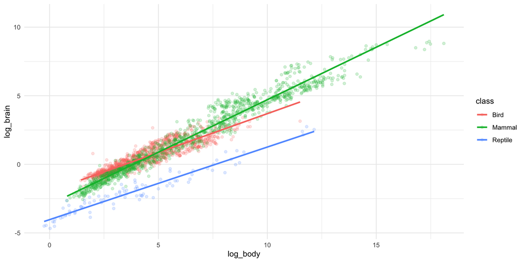

```r
# Create final plot with regression lines
ggplot(avg_weights, aes(x = log_body, y = log_brain, color = class)) +
  geom_point(alpha = 0.2) +
  geom_smooth(method = "lm", se = FALSE) +
  theme_minimal()
```

## Step 5: Analyze

So in this case there are three different linear relationships on the log scale that depend on animal class:

$$(\text{brain}) = \beta_1(\text{body})^{\alpha_1} \qquad \text{(mammal)} \\
(\text{brain}) = \beta_2(\text{body})^{\alpha_2} \qquad \text{(reptile)} \\
(\text{brain}) = \beta_3(\text{body})^{\alpha_3} \qquad \text{(bird)} \\
\beta_i \neq \beta_j, \alpha_i \neq \alpha_j \quad \text{for } i \neq j$$

# Data Science and story telling

## Data and story telling

[figure not shown]

A good story connects data to meaning.  
The challenge is this: do we tell the story we want to tell, or the one that the data spontaneously reveals (if any)?

## Cancer Deaths in the US

Do you think cancer deaths (per 100k people) have increased or decreased since 1980?

## What story does the data tell?

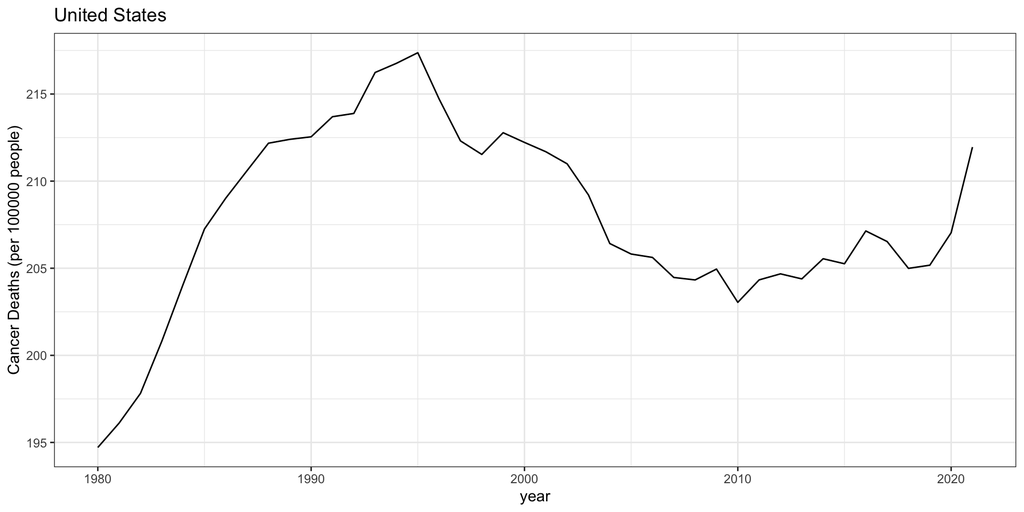

```r
cancer_data <- read_csv("data/IHME/IHME_cancer.csv")

cancer_data |> filter(cause_name == "Total cancers",
                      age_name == "All ages",
                      metric_name == "Rate",
                      location_name == "United States of America") |>
  ggplot() + geom_line(aes(x=year, y=val)) +
  theme_bw() +
  ylab("Cancer Deaths (per 100000 people)") +
  ggtitle("United States")
```

How do we describe the observed trend?

## What story does the data tell?

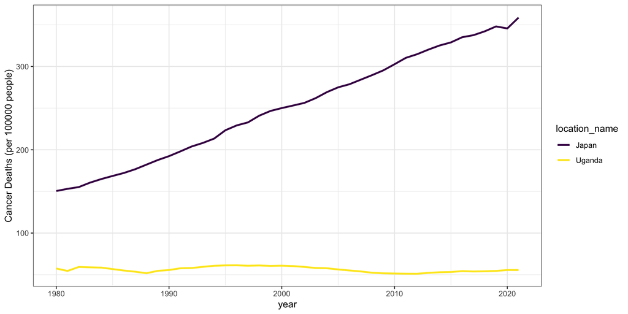

```r
cancer_data <- read_csv("data/IHME/IHME_cancer.csv")

cancer_data |> filter(cause_name == "Total cancers",
                      age_name == "All ages",
                      metric_name == "Rate",
                      location_name %in% c("Japan", "Uganda")) |>
  ggplot() +
  geom_line(aes(x=year, y=val, col=location_name), linewidth = 1) +
  theme_bw() +
  scale_color_viridis_d()+
  ylab("Cancer Deaths (per 100000 people)")
```

Story?

Only 2% of Uganda’s population is older than 65, against 30% in Japan.

## What story does the data tell?

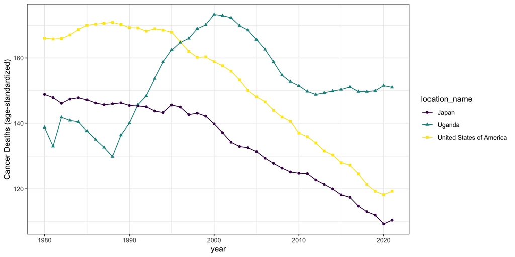

```r
cancer_data <- read_csv("data/IHME/IHME_cancer.csv")

cancer_data |> filter(cause_name == "Total cancers",
                      age_name == "Age-standardized",
                      metric_name == "Rate") |>
  ggplot() +
  geom_line(aes(x=year, y=val, col=location_name)) +
  geom_point(aes(x=year, y=val,
                 shape=location_name,
                 col=location_name)) +
  theme_bw() +
  scale_color_viridis_d()+
  ylab("Cancer Deaths (age-standardized)")
```

Age-standardized rates allow us to compare cancer death rates in Uganda and Japan as if they applied to two countries with identical age structures.

## Next

The Tidy data standard and basic data pipeline.